# Spatial autocorrelation

Peter Ralph

Advanced Biological Statistics

# Spatial models

## A simple scenario

Suppose we have estimates of abundance of a soil microbe from a number of samples across our study area:

[output not shown]

[figure not shown]

## The data

`(x,y)` : spatial coords; `z` : abundance

```r
xy
```

[output not shown]

**Goals:**

1. (descriptive) What spatial scale does abundance vary over?
2. (predictive) What are the likely (range of) abundances at new locations?

## Exercise:

Let’s brainstorm a few examples, listing

1. a spatially autocorrelated variable
2. the spatial scale of autocorrelation

# Spatial covariance

## Tobler’s First Law of Geography:

> Everything is related to everything else, but near things are more related than distant things.

*Modeler:* Great, covariance is a decreasing function of distance.

## A decreasing function of distance.

A convenient choice: the covariance between two points distance $d$ apart is
$$\begin{aligned}
\alpha^2 \exp\left(- \frac{1}{2}\left(\frac{d}{\rho}\right)^2 \right) .
\end{aligned}$$

- $\alpha$ controls the overall variance (amount of noise)
- $\rho$ is the spatial scale that covariance decays over

## In Stan

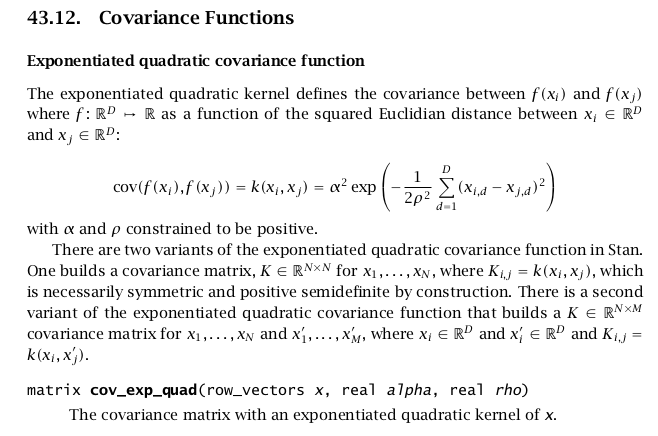

cov_exp_quad() documentation

## In brms: `~ gp( )`

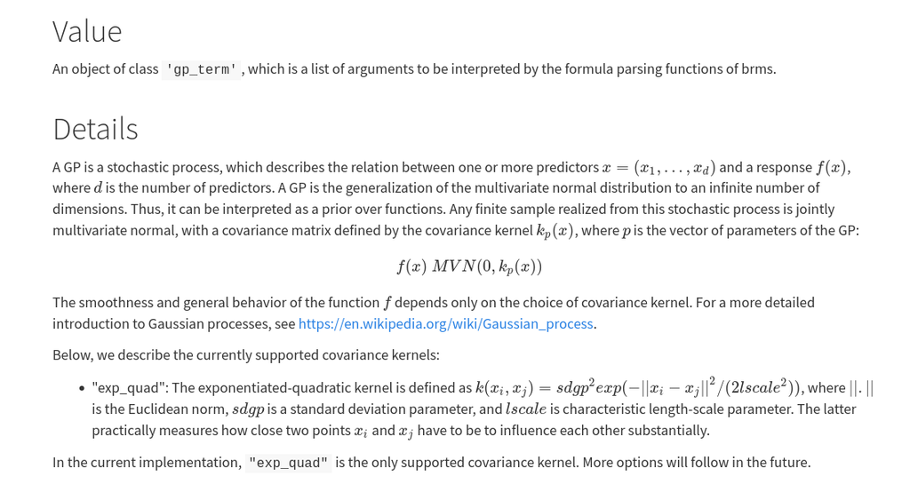

Here’s an `R` function that takes a set of locations (`xy`), a variance scaling `alpha`, and a spatial scale `rho`:

```r
cov_exp_quad <- function (xy, alpha, rho) {
    # return the 'quadratic exponential' covariance matrix
    # for spatial positions xy
    dxy <- as.matrix(dist(xy))
    return( alpha^2 * exp( - (1/2) * dxy^2 / rho^2 ) )
}
```

**Challenge:** simulate spatially autocorrelated random Gaussian values, and plot them, in space. Pick parameters so you can tell they are autocorrelated.

*Hint:* `library(mvtnorm)` and

```r
    # to color points by a continuous value:
    colorRampPalette(c('blue', 'red'))(24)[cut(xy$z, breaks=24)]
```

# Fitting a model

## Goals

1. (descriptive) What spatial scale does abundance vary over?

   $\Rightarrow$ What is $\rho$?
2. (predictive) What are the likely (range of) abundances at new locations?

   $\Rightarrow$ *Predict* at new locations.

## Simulate data

```r
N <- 20
xy <- data.frame(x=runif(N), y=runif(N))
dxy <- as.matrix(dist(xy))
ut <- upper.tri(dxy, diag=TRUE)
truth <- list(rho=.6,
              delta=.1,
              alpha=2.5,
              mu=5)
truth$covmat <- (truth$delta * diag(N)
                 + truth$alpha^2 * exp(-(dxy/truth$rho)^2))
xy$z <- as.vector(rmvnorm(1, mean=rep(truth$mu,N), sigma=truth$covmat))
```

## Pick priors?

Default looks okay:

```r
get_prior(z ~ gp(x, y), data=xy)
```

```
##                          prior     class coef group resp dpar nlpar bound       source
##         student_t(3, 2.6, 2.5) Intercept                                       default
##                         (flat)    lscale                                       default
##  inv_gamma(3.118793, 0.477592)    lscale gpxy                                  default
##           student_t(3, 0, 2.5)      sdgp                                       default
##           student_t(3, 0, 2.5)      sdgp gpxy                             (vectorized)
##           student_t(3, 0, 2.5)     sigma                                       default
```

## Fit the model

```r
sp_fit <- brm(
    z ~ gp(x, y),
    data=xy,
    file="cache/sp_fit.rds"
)
```

## Convergence issues

```
6: There were 114 divergent transitions after warmup. See
http://mc-stan.org/misc/warnings.html#divergent-transitions-after-warmup
to find out why this is a problem and how to eliminate them.
```

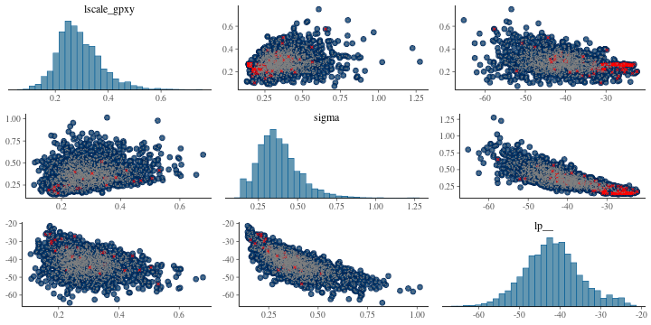

```r
mcmc_pairs(sp_fit, pars=c("lscale_gpxy", "sigma", "lp__"), np=nuts_params(sp_fit))
```

## Try again

```r
sp_fit <- brm(
    z ~ gp(x, y),
    data=xy,
    file="cache/sp_fit2.rds",
    control=list(adapt_delta=0.95)
)
```

```r
sp_fit
```

```
##  Family: gaussian
##   Links: mu = identity; sigma = identity
## Formula: z ~ gp(x, y)
##    Data: xy (Number of observations: 20)
##   Draws: 4 chains, each with iter = 2000; warmup = 1000; thin = 1;
##          total post-warmup draws = 4000
##
## Gaussian Process Terms:
##              Estimate Est.Error l-95% CI u-95% CI Rhat Bulk_ESS Tail_ESS
## sdgp(gpxy)       2.06      0.86     1.06     4.29 1.00     1317     2095
## lscale(gpxy)     0.29      0.08     0.16     0.49 1.00      724     1364
##
## Population-Level Effects:
##           Estimate Est.Error l-95% CI u-95% CI Rhat Bulk_ESS Tail_ESS
## Intercept     3.95      1.10     1.81     6.40 1.00     1232     1546
##
## Family Specific Parameters:
##       Estimate Est.Error l-95% CI u-95% CI Rhat Bulk_ESS Tail_ESS
## sigma     0.38      0.14     0.17     0.70 1.00      416      487
##
## Draws were sampled using sampling(NUTS). For each parameter, Bulk_ESS
## and Tail_ESS are effective sample size measures, and Rhat is the potential
## scale reduction factor on split chains (at convergence, Rhat = 1).
```

## Does it work?

```
##       truth  Estimate  l-95% CI  u-95% CI
## alpha   2.5 2.0578919 1.0641066 4.2856477
## rho     0.6 0.2900958 0.1569962 0.4918624
## delta   0.1 0.3764278 0.1673808 0.7031219
## mu        5 3.9465881 1.8106834 6.4013225
```

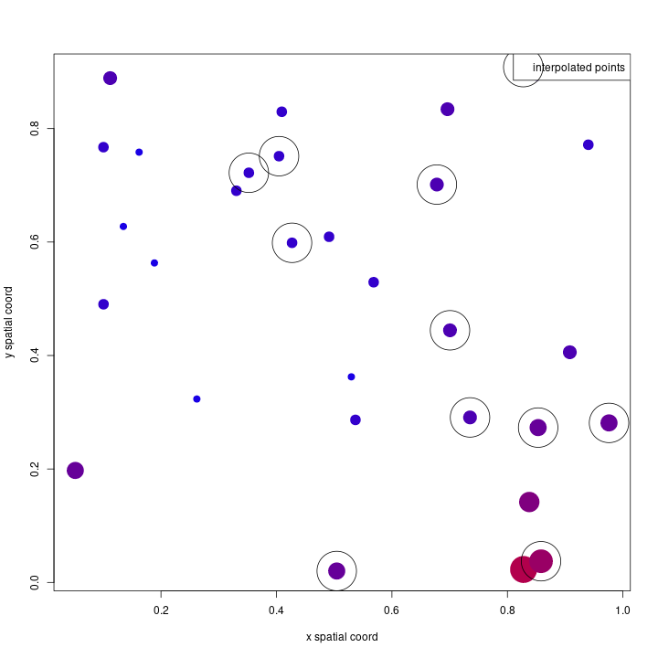

## Conclusions

   These are

```
##            x          y Estimate Est.Error     Q2.5    Q97.5
## 1  0.5043937 0.02017328 4.780138 1.1844345 2.485370 7.183125
## 2  0.4269982 0.59862324 2.059266 0.4867674 1.091640 3.029740
## 3  0.7352417 0.29087388 3.954424 0.5962007 2.776944 5.170327
## 4  0.3522130 0.72205000 2.194331 0.4675924 1.259577 3.148516
## 5  0.9759262 0.28120183 4.569030 0.7800587 2.988711 6.088379
## 6  0.8581954 0.03737987 6.786224 0.5491277 5.639697 7.806351
## 7  0.6778009 0.70130030 3.513884 0.6363478 2.194811 4.719990
## 8  0.8531732 0.27295228 4.550964 0.5707566 3.417724 5.716459
## 9  0.7005615 0.44442729 3.152045 0.6110838 1.956736 4.358987
## 10 0.4044683 0.75131957 2.490939 0.4752951 1.537279 3.457285
```

## Interpolating to a grid

```r
grid_xy <- expand.grid(x=seq(0,1,length.out=11), y=seq(0,1,length.out=11))
grid_pred <- predict(sp_fit, newdata=grid_xy)
```

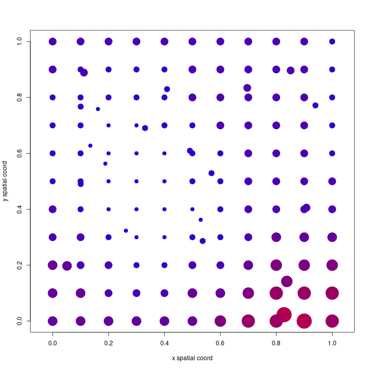